# STATS506_HW_04

github link: https://github.com/juanitaW12/stats506

## Load packages

```r
library(readr)
library(tidyverse)
library(nycflights13)
library(dplyr)
```

## **Problem 1 - Tidyverse**

### (a)

```r
# the mean and median departure delay per airport
departure_delays <- flights %>%
  group_by(origin) %>%
  summarise(
    avg_dep_delay = mean(dep_delay, na.rm = TRUE),  # the mean
    med_dep_delay = median(dep_delay, na.rm = TRUE), # the median
  ) %>%
  arrange(desc(avg_dep_delay)) %>%
  left_join(airports, by = c("origin" = "faa")) %>% # join airports to get the name of airports
  select(airport_name = name, avg_dep_delay, med_dep_delay)
```

```r
# print departure delays tibble
departure_delays
```

```
# A tibble: 3 × 3
  airport_name        avg_dep_delay med_dep_delay
  <chr>                       <dbl>         <dbl>
1 Newark Liberty Intl          15.1            -1
2 John F Kennedy Intl          12.1            -1
3 La Guardia                   10.3            -3
```

```r
# the mean and median arrival delay per airport
arrival_delays <- flights %>%
  group_by(dest) %>%
  summarise(
    avg_arr_delay = mean(arr_delay, na.rm = TRUE),
    med_arr_delay = median(arr_delay, na.rm = TRUE),
    flight_count = n()
  ) %>%
  filter(flight_count >= 10) %>%
  arrange(desc(avg_arr_delay)) %>%
  left_join(airports, by = c("dest" = "faa")) %>%
  select(airport_name = name, avg_arr_delay, med_arr_delay, flight_count)
```

```r
# print arrival delays tibble
print(arrival_delays)
```

```
# A tibble: 102 × 4
   airport_name                  avg_arr_delay med_arr_delay flight_count
   <chr>                                 <dbl>         <dbl>        <int>
 1 Columbia Metropolitan                  41.8            28          116
 2 Tulsa Intl                             33.7            14          315
 3 Will Rogers World                      30.6            16          346
 4 Jackson Hole Airport                   28.1            15           25
 5 Mc Ghee Tyson                          24.1             2          631
 6 Dane Co Rgnl Truax Fld                 20.2             1          572
 7 Richmond Intl                          20.1             1         2454
 8 Akron Canton Regional Airport          19.7             3          864
 9 Des Moines Intl                        19.0             0          569
10 Gerald R Ford Intl                     18.2             1          765
# ℹ 92 more rows
```

### (b)

```r
fastest_plane_model <- flights %>%
  # calculate the hourly speed of every flight
  mutate(fight_speed = distance / (air_time / 60)) %>%
  left_join(planes, by = "tailnum") %>% # to get the model name
  group_by(model) %>%
  summarise(
    avg_speed = mean(fight_speed),
    flight_count = n()
  ) %>%
  arrange(desc(avg_speed)) %>%
  slice(1) %>%
  select(model, avg_speed, flight_count)
```

```r
print(fastest_plane_model)
```

```
# A tibble: 1 × 3
  model   avg_speed flight_count
  <chr>       <dbl>        <int>
1 777-222      483.            4
```

## **Problem 2 - `get_temp()`**

```r
nnmaps = read.csv('./chicago-nmmaps.csv')
```

```r
get_temp <- function(month, year, data, celsius = FALSE, average_fn = mean) {

  # convert any format of the month to number
  # if month is a number, month = month
  # if month is a character
  if (is.character(month)) {
    month_numeric <- match(tolower(month), tolower(month.abb))

    # if not matching
    if (is.na(month_numeric)) {
      month_numeric <- match(tolower(month), tolower(month.name))
    }

    month <- month_numeric
  }

  # set error warning
  if (is.na(month) || month < 1 || month > 12) {
    print(" Please input a month as a number (1-12) or a string (e.g., 'Apr').")
  }

  # filter data and calculate average temperature
  result <- data %>%
    filter(year == !!year, month_numeric == !!month) %>%
    summarise(avg_temp = average_fn(temp)) %>%
    pull(avg_temp) # select the single value

  # convert celsius to fahrenheit
  if (celsius) { # if celsius = TRUE
    result <- (result * 1.8) + 32
  }

  return(result)
}
```

```r
get_temp("Apr", 1999, data = nnmaps)
```

```
[1] 49.8
```

```r
get_temp("Apr", 1999, data = nnmaps, celsius = TRUE)
```

```
[1] 121.64
```

```r
get_temp(10, 1998, data = nnmaps, average_fn = median)
```

```
[1] 55
```

```r
get_temp(13, 1998, data = nnmaps)
```

```
[1] " Please input a month as a number (1-12) or a string (e.g., 'Apr')."
```

```
[1] NaN
```

```r
get_temp(2, 2005, data = nnmaps)
```

```
[1] NaN
```

```r
get_temp("November", 1999, data =nnmaps, celsius = TRUE,
         average_fn = function(x) {
           x %>% sort -> x
           x[2:(length(x) - 1)] %>% mean %>% return
         })
```

```
[1] 113.2571
```

## **Problem 3 - Visualization**

```r
market = read.csv("./df_for_ml_improved_new_market.csv")
```

### (a)

```r
# calculate the average price of years
# create a line plot for average price over year
avg_price_plot <- market %>%
  group_by(year) %>%
  summarise(avg_price = mean(price_usd)) %>%
  ggplot(aes(x = year, y = avg_price)) +
  geom_line(color = "blue", linewidth = 1) +
  geom_point(size = 3, color = "red") +
  labs(title = "Average Price(USD) Over Years",
       x = "Year",
       y = "Average Price (USD)") +
  theme_minimal() +
  theme(text = element_text(size = 12))
```

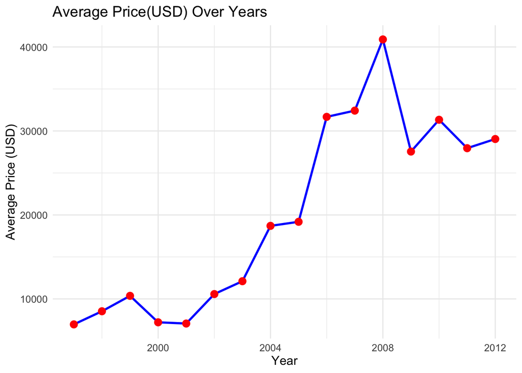

```r
print(avg_price_plot)
```

As shown above, there is a change in the sales price in USD over the years. Starting in 2001, the average sales price steadily increased from below 10,000 USD to over 40,000 USD in 2008. Then, the price fell below 30,000 USD, with slight fluctuations from 2008 to 2012.

### (b)

The genres are divided into five kinds: “Photography”, “Print”, “Sculpture”, “Painting” and “Others”.

```r
market_genre <- market %>%
  pivot_longer(cols = starts_with("Genre_"), names_to = "genre", values_to = "present") %>%
  filter(present == 1) %>% # filter data whose genre is 1
  select(case_id, year, genre, price_usd)
```

Firstly, I created a percentage bar chart of genres for every year to see the whether the percentage of genres would change.

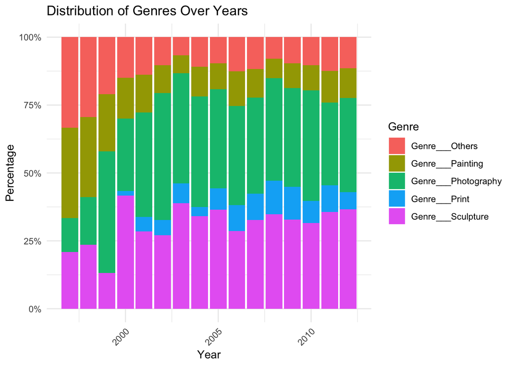

```r
ggplot(market_genre, aes(x = year, fill = genre)) +
  geom_bar(position = "fill") +
  scale_y_continuous(labels = scales::percent_format()) +
  labs(title = "Distribution of Genres Over Years",
       x = "Year",
       y = "Percentage",
       fill = "Genre") +
  theme_minimal() +
  theme(axis.text.x = element_text(angle = 45, hjust = 1))
```

The category “Others” saw a significant decrease in percentage from 1997 to 2003, followed by fluctuations in the subsequent years.

Painting exhibits a similar trend.

Photography started with a lower percentage in the late 1990s but has gradually increased over time. Then this genre shows a steady rise and appears to stabilize in the later years.

From 1997 to 2000, the percentage of printing is very low. And from 2001 to 2012, printing has maintained a relatively consistent proportion over the years, with only minor fluctuations, showing no significant upward or downward trends.

Sculpture firstly significantly increased form 1999 to 2001 and has kept a steady proportion throughout the years, with slight fluctuations and no major trends in increasing or decreasing direction.

In summary, while genres like “Others” and “Painting” experienced initial declines, Photography has shown gradual growth, and Sculpture has remained stable. This suggests shifts in artistic interests over the years, with a rise in Photography and sustained interest in Sculpture.

Then, I calculated the sales of each genres and created stacked bar chart to see if the sales had changes.

```r
genre_sales <- market_genre %>%
  group_by(year, genre) %>%
  summarize(total_genre_sales = sum(price_usd),.groups = 'drop') %>%
  ungroup()
```

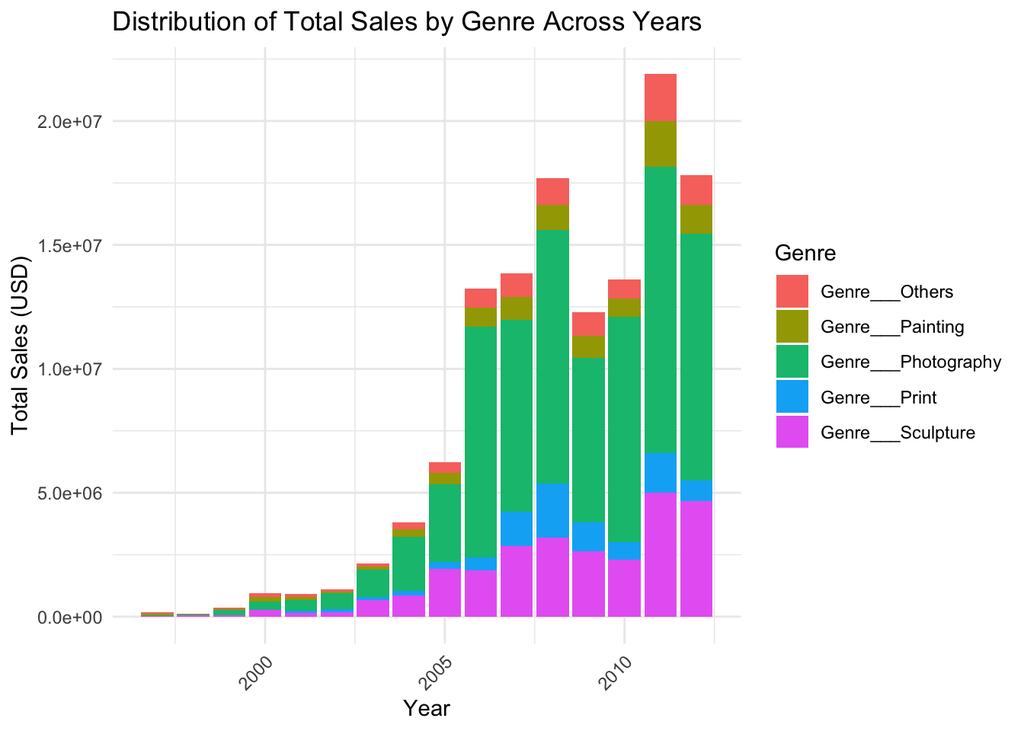

```r
ggplot(genre_sales, aes(x = year, y = total_genre_sales, fill = genre)) +
  geom_bar(stat = "identity", position = "stack") +
  labs(title = "Distribution of Total Sales by Genre Across Years",
       x = "Year",
       y = "Total Sales (USD)",
       fill = "Genre") +
  theme_minimal() +
  theme(axis.text.x = element_text(angle = 45, hjust = 1))
```

The “Others” category saw sporadic increased from 1997 to around 2008 with fluctuations in the following years.

Print remained relatively modest throughout the years, with a dramatic changes before and after 2006. But print genre consistently represented a small share of total sales.

### (c)

In this section, I generated line plots of average price for each genre to see the yearly change.

```r
# calculate the avearge price for each genre
genre_avg_price <- market_genre %>%
  group_by(year, genre) %>%
  summarize(avg_price_usd = mean(price_usd), .groups = 'drop')
```

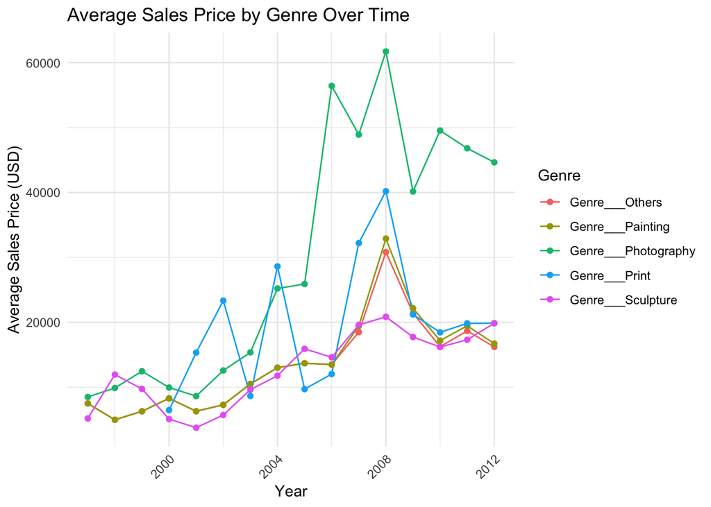

```r
ggplot(genre_avg_price, aes(x = year, y = avg_price_usd, color = genre, group = genre)) +
  geom_line() +
  geom_point() +
  labs(title = "Average Sales Price by Genre Over Time",
       x = "Year",
       y = "Average Sales Price (USD)",
       color = "Genre") +
  theme_minimal() +
  theme(axis.text.x = element_text(angle = 45, hjust = 1))
```

Overall, the average price for each genre shows an upward trend, peaking in 2008. After that, the prices experienced a slight decline followed by minor fluctuations.